# team

Xinyi Zhu, Han Sun

3/21/2020

### Part one: Cleaning Data Frame

```r
library(ggplot2)
library(dplyr)
library(tidyr)
library(readxl)
# import defense sheet
defense <- read_excel('cyclonesFootball2019.xlsx', sheet='Defensive')
# import offense sheet
offense <- read_excel('cyclonesFootball2019.xlsx', sheet='Offensive')
# import biography sheet
biography <- read_excel('cyclonesFootball2019.xlsx', sheet='Biography')
```

1. The player names and opponent names are factors.

```r
defense$Name <- as.factor(defense$Name)
defense$Opponent_Opponent <- as.factor(defense$Opponent_Opponent)

offense$Name <- as.factor(offense$Name)
offense$Opponent_Opponent <- as.factor(offense$Opponent_Opponent)

biography$Name <- as.factor(biography$Name)
```

2. All offensive and defensive statistics are numerical. The Weight column in biogrpahy is also numeric.

```r
defClean <- defense %>%
  mutate(Tackles_Solo = as.numeric(Tackles_Solo),
         Tackles_ASST = as.numeric(Tackles_ASST),
         Tackles_TFL = as.numeric(Tackles_TFL),
         Tackles_Sack = as.numeric(Tackles_Sack),
         Turnover_FF = as.numeric(Turnover_FF),
         Turnover_FR = as.numeric(Turnover_FR),
         Turnover_INT = as.numeric(Turnover_INT),
         Pass_QBH = as.numeric(Pass_QBH),
         Pass_PB = as.numeric(Pass_PB))

names(offense)[9] <- "Passing_CMP_ATT"
offClean <- offense %>%
  mutate(Rushing_ATT = as.numeric(Rushing_ATT),
         Rushing_YDS = as.numeric(Rushing_YDS),
         Rushing_TD = as.numeric(Rushing_TD),
         Receiving_REC = as.numeric(Receiving_REC),
         Receiving_YDS = as.numeric(Receiving_YDS),
         Receiving_TD = as.numeric(Receiving_TD),
         Passing_CMP_ATT = as.numeric(Passing_CMP_ATT),
         Passing_YDS = as.numeric(Passing_YDS),
         Passing_TD = as.numeric(Passing_TD),
         Passing_INT = as.numeric(Passing_INT))
```

```r
offClean[is.na(offClean)] = 0

bioClean <- biography %>%
  mutate(Weight = as.numeric(Weight))
```

3. Change the Height column in biogrpahy into numeric.

```r
bioClean <- bioClean %>%
  separate('Height', into = c("Feet", "Inch")) %>%
  mutate_at('Feet', as.numeric)%>%
  mutate_at('Inch', as.numeric)
bioClean$Height <- bioClean$Inch + bioClean$Feet * 12
head(bioClean)
```

```
## # A tibble: 6 x 9
##   Name      Position    Feet  Inch Weight Class    Hometown    Highschool Height
##   <fct>     <chr>      <dbl> <dbl>  <dbl> <chr>    <chr>       <chr>       <dbl>
## 1 Akers, L~ Wide Rece~     6     0    188 Redshir~ Cedar Rapi~ Washington     72
## 2 Allen, C~ Tight End      6     7    245 Redshir~ Nixa, Mo.   Nixa           79
## 3 Anderson~ Wide Rece~     6     5    204 Redshir~ Seffner, F~ Armwood        77
## 4 Assalley~ Placekick~     6     0    195 Redshir~ Naperville~ Central        72
## 5 Azunna, ~ Defensive~     6     0    190 Redshir~ Grand Prai~ Lake Ridge     72
## 6 Bailey, ~ Defensive~     6     3    235 Redshir~ Clarksdale~ Clarksdale     75
```

By cleaning the three data frames in R, at the end of this step you should have the following three clean data frames: defClean, offClean, and bioClean. Print the structures of these data frames.

```r
str(defClean)
```

```
## Classes 'tbl_df', 'tbl' and 'data.frame':    502 obs. of  11 variables:
##  $ Name             : Factor w/ 43 levels "Akers, Landen",..: 40 40 40 40 40 40 40 40 40 40 ...
##  $ Opponent_Opponent: Factor w/ 13 levels "Baylor","Iowa",..: 12 2 11 1 8 13 10 7 6 9 ...
##  $ Tackles_Solo     : num  4 4 3 4 3 1 7 3 6 5 ...
##  $ Tackles_ASST     : num  4 7 5 2 2 1 1 2 1 5 ...
##  $ Tackles_TFL      : num  0 0 0 0 1 0 0 0 1 1 ...
##  $ Tackles_Sack     : num  0 0 0 0 0 0 0 0 0 1 ...
##  $ Turnover_FF      : num  0 0 0 0 0 0 0 0 0 0 ...
##  $ Turnover_FR      : num  0 0 0 0 0 0 0 0 0 0 ...
##  $ Turnover_INT     : num  0 0 1 0 0 0 0 0 1 0 ...
##  $ Pass_QBH         : num  1 0 0 0 0 0 0 0 1 0 ...
##  $ Pass_PB          : num  1 2 0 0 0 1 0 0 0 0 ...
```

```r
str(offClean)
```

```
## Classes 'tbl_df', 'tbl' and 'data.frame':    195 obs. of  12 variables:
##  $ Name             : Factor w/ 17 levels "Akers, Landen",..: 1 1 1 1 1 1 1 1 1 1 ...
##  $ Opponent_Opponent: Factor w/ 13 levels "Baylor","Iowa",..: 12 2 11 1 8 13 10 7 6 9 ...
##  $ Rushing_ATT      : num  0 0 1 0 0 0 0 0 0 0 ...
##  $ Rushing_YDS      : num  0 0 8 0 0 0 0 0 0 0 ...
##  $ Rushing_TD       : num  0 0 0 0 0 0 0 0 0 0 ...
##  $ Receiving_REC    : num  1 0 0 0 1 0 0 4 0 1 ...
##  $ Receiving_YDS    : num  21 0 0 0 32 0 0 39 0 7 ...
##  $ Receiving_TD     : num  0 0 0 0 0 0 0 0 0 0 ...
##  $ Passing_CMP_ATT  : num  0 0 0 0 0 0 0 0 0 0 ...
##  $ Passing_YDS      : num  0 0 0 0 0 0 0 0 0 0 ...
##  $ Passing_TD       : num  0 0 0 0 0 0 0 0 0 0 ...
##  $ Passing_INT      : num  0 0 0 0 0 0 0 0 0 0 ...
```

```r
str(bioClean)
```

```
## Classes 'tbl_df', 'tbl' and 'data.frame':    105 obs. of  9 variables:
##  $ Name      : Factor w/ 105 levels "Akers, Landen",..: 1 2 3 4 5 6 7 8 9 10 ...
##  $ Position  : chr  "Wide Receiver" "Tight End" "Wide Receiver" "Placekicker" ...
##  $ Feet      : num  6 6 6 6 6 6 6 6 6 6 ...
##  $ Inch      : num  0 7 5 0 0 3 2 2 0 6 ...
##  $ Weight    : num  188 245 204 195 190 235 255 285 300 215 ...
##  $ Class     : chr  "Redshirt Senior" "Redshirt Senior" "Redshirt Freshman" "Redshirt Senior" ...
##  $ Hometown  : chr  "Cedar Rapids, Iowa" "Nixa, Mo." "Seffner, Fla." "Naperville, Ill." ...
##  $ Highschool: chr  "Washington" "Nixa" "Armwood" "Central" ...
##  $ Height    : num  72 79 77 72 72 75 74 74 72 78 ...
```

### Part two: Tidying (1)

1. Reformat the defClean data frame into a tidy format using pivot_longer. The type of statistic (Tackles_Solo, Tackles_ASST, etc) is added as a new key column named Statistic.

```r
defClean <- defClean %>%
  pivot_longer(Tackles_Solo:Pass_PB, names_to = 'Statistic')
head(defClean)
```

```
## # A tibble: 6 x 4
##   Name            Opponent_Opponent Statistic    value
##   <fct>           <fct>             <chr>        <dbl>
## 1 White, Lawrence UNI               Tackles_Solo     4
## 2 White, Lawrence UNI               Tackles_ASST     4
## 3 White, Lawrence UNI               Tackles_TFL      0
## 4 White, Lawrence UNI               Tackles_Sack     0
## 5 White, Lawrence UNI               Turnover_FF      0
## 6 White, Lawrence UNI               Turnover_FR      0
```

2. Create a histogram for each defensive statistic. Use facet_wrap to draw all histograms in a single plot. What defensive skills are rare?

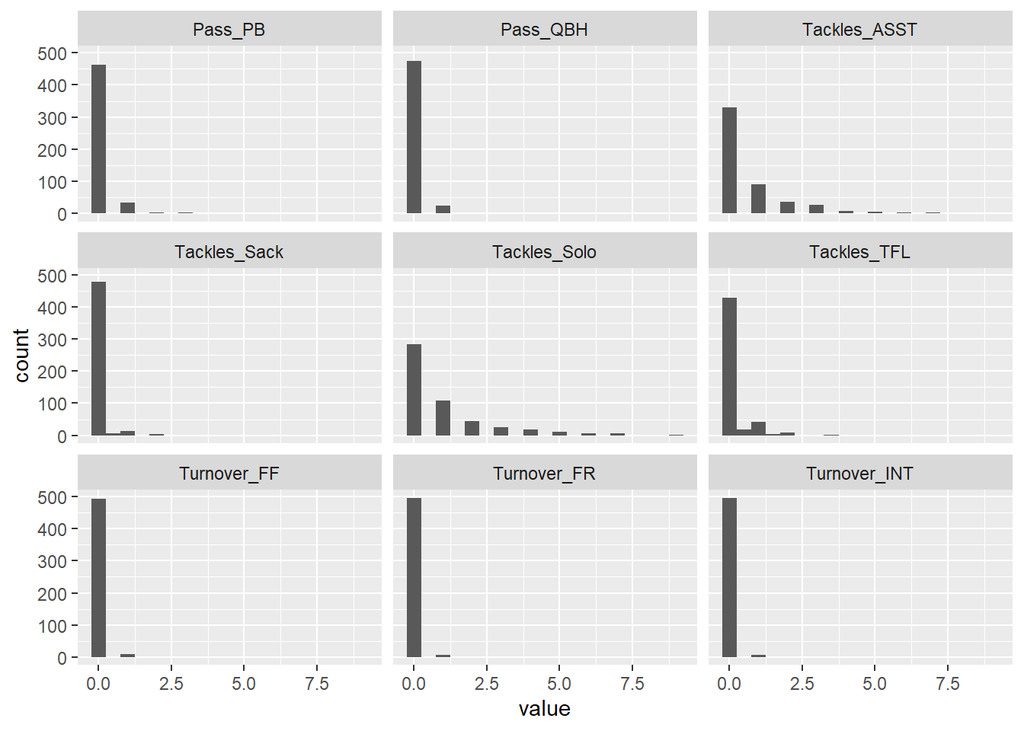

```r
defClean %>%
  ggplot(aes(value)) + geom_histogram(binwidth = 0.5) + facet_wrap(~Statistic)
```

From the defensive histograms, the Tackles_Sack, Turnover_FF, Turnover_FR, Turnover_INT skills are rare.

3. Did ISU have better defense against West Virginia or Kansas State? Answer this question by creating a scatterplot with x-axis being the number of solo tackles (by each player) against West Virginia, and y-axis being that against Kansas State. A large number of solo tackles indicates good defense.

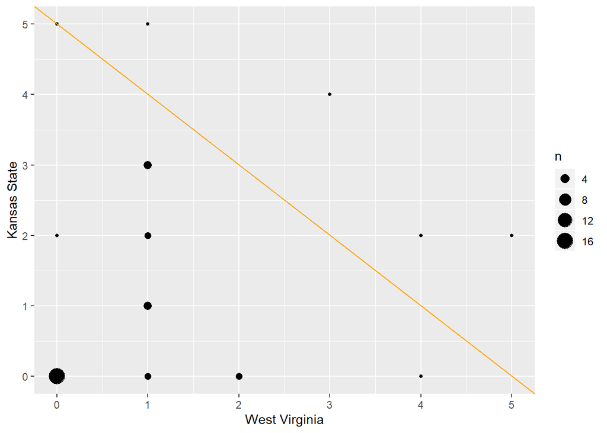

```r
defClean %>%
  filter(Statistic == "Tackles_Solo", Opponent_Opponent %in% c("West Virginia", "Kansas State")) %>%
  spread(Opponent_Opponent,value) %>%
  ggplot(aes(x = `West Virginia`, y = `Kansas State`)) + geom_count() + geom_abline(slope = -1, intercept = 5, colour = "orange")
```

### Part two: Tidying (2)

1. Separate the Hometown column into two columns, namely the city and the state. Print the first few rows of these two columns. (Hint: look at the sep= argument of separate)

```r
bioClean <- bioClean %>%
  separate(Hometown, into = c('City', 'State'), sep = ",")
head(bioClean)
```

```
## # A tibble: 6 x 10
##   Name     Position    Feet  Inch Weight Class    City   State Highschool Height
##   <fct>    <chr>      <dbl> <dbl>  <dbl> <chr>    <chr>  <chr> <chr>       <dbl>
## 1 Akers, ~ Wide Rece~     6     0    188 Redshir~ Cedar~ " Io~ Washington     72
## 2 Allen, ~ Tight End      6     7    245 Redshir~ Nixa   " Mo~ Nixa           79
## 3 Anderso~ Wide Rece~     6     5    204 Redshir~ Seffn~ " Fl~ Armwood        77
## 4 Assalle~ Placekick~     6     0    195 Redshir~ Naper~ " Il~ Central        72
## 5 Azunna,~ Defensive~     6     0    190 Redshir~ Grand~ " Te~ Lake Ridge     72
## 6 Bailey,~ Defensive~     6     3    235 Redshir~ Clark~ " Mi~ Clarksdale     75
```

2. How many players are there from each state?

```r
table(bioClean$State)
```

```
##
##      Ariz.       Ark.  Australia     Calif.       Fla.        Ga.       Ill.
##          4          1          1          3         10          4          5
##       Iowa       Kan.      Mich.      Minn.      Miss.        Mo.       Ohio
##         35          3          4          4          1          6          7
##      Okla.        Pa.       S.D.      Texas       Wis.
##          2          1          2          6          6
```

### Part three: Joining data frames

1. Find where do the offensive players come from by joining the offensive data and player biography data appropriately.

```r
left <- left_join(offClean, bioClean, by = "Name")
leftns <- left %>%
   select("Name", "State")
unique(leftns)
```

```
## # A tibble: 17 x 2
##    Name                State
##    <chr>               <chr>
##  1 Akers, Landen       " Iowa"
##  2 Soehner, Dylan      " Ark."
##  3 Allen, Chase        " Mo."
##  4 Wilson, Darren      " Ga."
##  5 Kolar, Charlie      " Okla."
##  6 Pettway, La'Michael  <NA>
##  7 Hall, Breece        " Kan."
##  8 Shaw Jr., Sean      " Okla."
##  9 Purdy, Brock        " Ariz."
## 10 Lang, Johnnie       " Fla."
## 11 Nwangwu, Kene       " Texas"
## 12 Mitchell, Re-al      <NA>
## 13 Croney Jr., Sheldon  <NA>
## 14 Brock, Jirehl       " Ill."
## 15 Jones, Deshaunte     <NA>
## 16 Milton, Tarique     " Fla."
## 17 Scates, Joe         " Ohio"
```

You can looking for hometown column from the table then find where do the offensive players come from.

2. Is there a relationship between the weight of a player and the receiving yards (Receiving_YDS)?

```r
full <- full_join(offClean, bioClean, by = "Name")
```

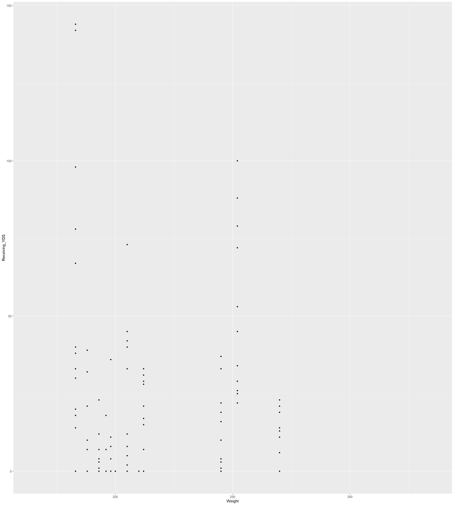

```r
ggplot(data =full, aes(x = Weight, y = Receiving_YDS)) +
  geom_point()
```

3. How do the performance of quarterback Brock Purdy relate to the performance of the ISU team?

```r
inner <- inner_join(offClean, bioClean, by = "Name")
```

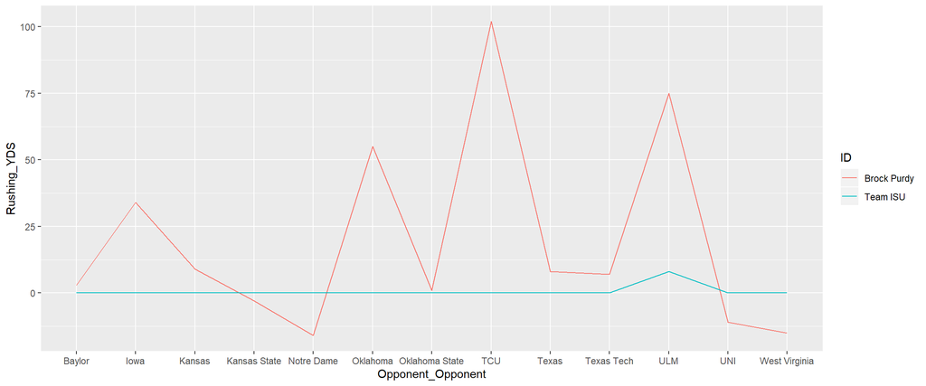

```r
TeamISU <- inner %>%
  filter(State == " Iowa") %>%
  group_by(Opponent_Opponent) %>%
  summarize(Rushing_YDS = sum(Rushing_YDS, na.rm = T),
            Rushing_ATT = sum(Rushing_ATT, na.rm = T),
            Rushing_TD = sum(Rushing_TD, na.rm = T),
            Receiving_REC = sum(Receiving_REC, na.rm = T),
            Receiving_YDS = sum(Receiving_YDS, na.rm = T),
            Receiving_TD = sum(Receiving_TD, na.rm = T),
            Passing_CMP_ATT = sum(Passing_CMP_ATT, na.rm = T),
            Passing_YDS = sum(Passing_YDS, na.rm = T),
            Passing_TD = sum(Passing_TD, na.rm = T),
            Passing_INT = sum(Passing_INT, na.rm = T)) %>%
  mutate(ID = "Team ISU")
BP <- inner %>%
  filter(Name == "Purdy, Brock") %>%
  group_by(Opponent_Opponent) %>%
  summarize(Rushing_YDS = sum(Rushing_YDS, na.rm = T),
            Rushing_ATT = sum(Rushing_ATT, na.rm = T),
            Rushing_TD = sum(Rushing_TD, na.rm = T),
            Receiving_REC = sum(Receiving_REC, na.rm = T),
            Receiving_YDS = sum(Receiving_YDS, na.rm = T),
            Receiving_TD = sum(Receiving_TD, na.rm = T),
            Passing_CMP_ATT = sum(Passing_CMP_ATT, na.rm = T),
            Passing_YDS = sum(Passing_YDS, na.rm = T),
            Passing_TD = sum(Passing_TD, na.rm = T),
            Passing_INT = sum(Passing_INT, na.rm = T)) %>%
  mutate(ID = "Brock Purdy")
Sum <- full_join(TeamISU, BP, by = c("ID", "Opponent_Opponent", "Rushing_YDS", "Rushing_ATT", "Rushing_TD", "Receiving_REC", "Receiving_YDS", "Receiving_TD", "Passing_CMP_ATT", "Passing_YDS", "Passing_TD", "Passing_INT"))
ggplot(data = Sum, aes(x = Opponent_Opponent, y = Rushing_YDS, group = ID, col = ID)) + geom_line()
```

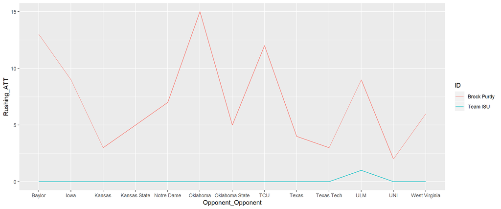

```r
ggplot(data = Sum, aes(x = Opponent_Opponent, y = Rushing_ATT, group = ID, col = ID)) + geom_line()
```

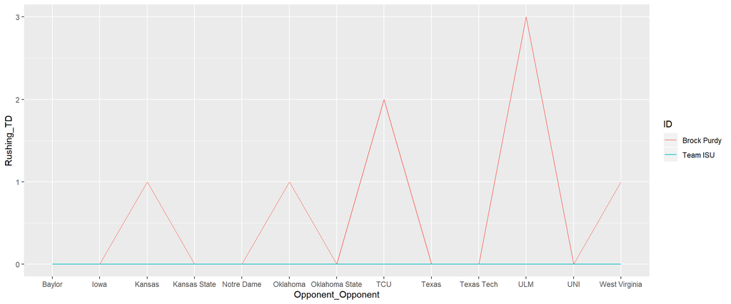

```r
ggplot(data = Sum, aes(x = Opponent_Opponent, y = Rushing_TD, group = ID, col = ID)) + geom_line()
```

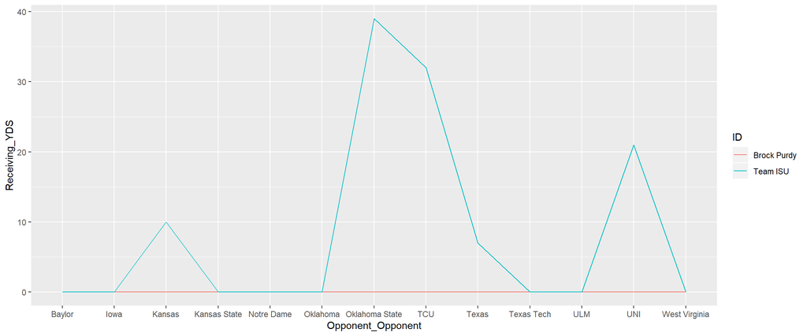

```r
ggplot(data = Sum, aes(x = Opponent_Opponent, y = Receiving_YDS, group = ID, col = ID)) + geom_line()
```

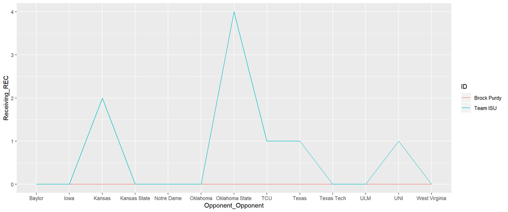

```r
ggplot(data = Sum, aes(x = Opponent_Opponent, y = Receiving_REC, group = ID, col = ID)) + geom_line()
```

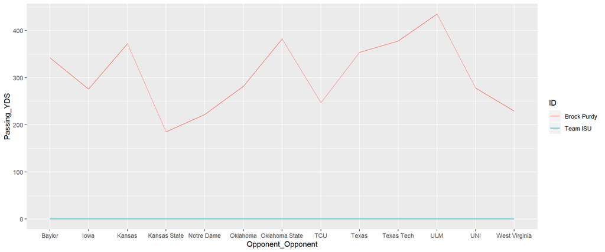

```r
ggplot(data = Sum, aes(x = Opponent_Opponent, y = Passing_YDS, group = ID, col = ID)) + geom_line()
```

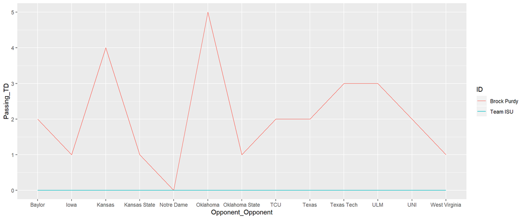

```r
ggplot(data = Sum, aes(x = Opponent_Opponent, y = Passing_TD, group = ID, col = ID)) + geom_line()
```

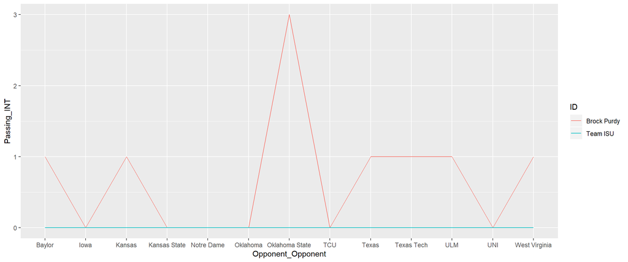

```r
ggplot(data = Sum, aes(x = Opponent_Opponent, y = Passing_INT, group = ID, col = ID)) + geom_line()
```

4. Explore more. You may in addition explore the 2018 data here. Raise a question that can be answered only by looking at two or more data frames. Then answer that question.

Is there a relationship between the Height(in inch) of a player and the receiving yards (Receiving_YDS)?

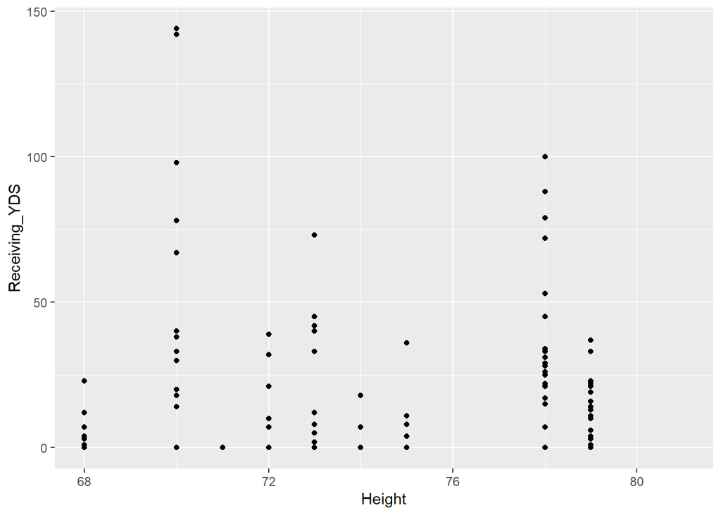

```r
ggplot(data =full, aes(x = Height, y = Receiving_YDS)) +
  geom_point()
```